# Manipulating datasets with the tidyverse package

Translational Data Science Part 1 - S1

# Session overview

## Description

In this session you will work with different data types, manipulate datasets and perform repetitive operations using a lot of the commands that come with the `tidyverse` package. You will also use the `apply` family of functions as you will encounter a lot of code in the Term 2 modules using this family of functions.

To help you with this session, you are going to put yourself in the shoes of a (fictional) researcher here at Imperial College London, Françoise Medici, and help her with a problem that involves:

1. merging two datasets;
2. performing some quality control checks on the data.

## Packages required

For this session you will need to install the `tidyverse` package. This package installs several other R packages that are commonly used for data tidying, data wrangling and data visualisation. Here we will mostly use functions from the `dplyr` package, which is also loaded with `tidyverse`. For more details on `tidyverse` and how to use it see the following websites:

- [the tidyverse package](https://www.tidyverse.org)
- [R for Data Science](https://r4ds.had.co.nz) - the “bible” of R (at the moment) written by [Hadley Wickham](http://hadley.nz/) and [Garrett Grolemund](https://twitter.com/statgarrett?lang=en)

## Data

The data for this tutorial can be found in the folder `Data` found in the folder for this session. It consists of two csv files:

- London_Paris_full.csv
- London_Paris_Jan_geno.csv

# Refresher on different R objects and data structures

Depending on your knowledge of R, you might need to do a refresher on some of the basic data types and structures in R. Rather than reinvent the wheel, we have found a very good [Software Carpentry](https://software-carpentry.org/) tutorial that has this exact same purpose - refreshing/introducing you to the different R data types and structures. You can access the tutorial [here](http://swcarpentry.github.io/r-novice-inflammation/13-supp-data-structures/index.html). In your spare time you can also check out their [other lessons](https://software-carpentry.org/lessons/).

# Manipulating datasets with the `tidyverse` package

As mentioned above in this section we are going to put ourselves in the shoes of a researcher that needs to merge two datasets and perfom some quality control checks on the data.

## The problem

Françoise has been working on a project for the last year which involves implementing a complex algorithm on a dataset to determine the time to diganosis of a particular cancer using genotype information. Up until this point, to test her algorithm, she has been using a pseudo-simulated dataset. Part of the pseduo-simulated data contains the characteristics of 1000 individuals of the London_Paris study contained in the dataset `London_Paris_full`. The other part contains the simulated genotypes of the `London_Paris` individuals.

Last month, her collaborator sent her the real genotype data for 500 individuals of the London_Paris study in a file called `London_Paris_Jan_geno.csv`. Françoise is keen to test her algorithm on the real genotype data as soon as possible but has noticed a problem: the data her collaborator sent, doesn’t have all the characteristics of the individuals that she needs to run her algorithm on.

For her algorithm, she requires the following characteristics of each individual, where dates are coded as YYYYMMDD

- `sample_id` - study id
- `dob` - date of birth
- `dor` - date of recruitment in the study
- `dod` - date of death, coded as 19000101 for alive participants
- `dodiag` - date of diagnosis, coded as 19000101 for controls
- `cc_status` - case control status, 0 - control, 1 - case
- `smoke_status` - smoking status, 1 - never smoked, 2 - former smoker, 3 - current smoker
- `vit_status` - vital status, 1 - alive, 2 - dead
- `a_sta_smok` - age the individual started smoking, coded as 120 for never smokers
- `a_quit_smok` - age the individual stopped smoking, coded as 120 for current ans never smokers
- `age_recr` - age at recruitment in study
- columns with genotype information for each individual.

Her goal is to create a dataset that contains all of the relevant columns for the 500 individuals for which she has the real genotype data and that ultimately looks like the below:

| sample_id | dob | dor | dod | dodiag | cc_status | smoke_status | vit_status | a_sta_smok | a_quit_smok | age_recr | SNP1 | SNP2 | SNP3 | SNP4 | SNP5 |
| --- | --- | --- | --- | --- | --- | --- | --- | --- | --- | --- | --- | --- | --- | --- | --- |
| A00001_0002 | 19281227 | 19970429 | 19000101 | 19000101 | 0 | 3 | 1 | 15 | 120 | 67.4935 | 1 | 2 | 2 | 1 | 0 |
| A00001_0003 | 19540125 | 19970408 | 19000101 | 19990517 | 0 | 2 | 1 | 15 | 52 | 54.43121 | 2 | 2 | 0 | 0 | 2 |
| A00001_0012 | 19530815 | 19960315 | 19000101 | 19000101 | 0 | 1 | 1 | 36 | 64 | 48.97194 | 1 | 1 | 0 | 1 | 0 |
| A00001_0023 | 19390801 | 19930618 | 20060818 | 20000912 | 0 | 3 | 2 | 36 | 120 | 54.35455 | 0 | 0 | 2 | 0 | 1 |
| A00001_0024 | 19560911 | 19950627 | 19000101 | 19000101 | 0 | 1 | 1 | 18 | 61 | 46.59822 | 1 | 0 | 0 | 2 | 0 |
| A00001_0025 | 19530815 | 19950421 | 20050804 | 20070117 | 0 | 1 | 1 | 120 | 120 | 56.57769 | 1 | 0 | 2 | 2 | 1 |

Once she has created the dataset above she has to perform the following checks:

1. the date of diagnosis has to be greater than the recruitment date
2. the date of diagnosis has to be greater than the birth date
3. the recruitment date has to be greater than the birth date
4. if a patient has been diagnosed with lung cancer and the patient died, than the death date has to be greater than the diagnosis date
5. the date of death has to be greater than the recruitment date
6. if the vital_status = 1 then no death date should be observed
7. if the vital_status = 2 then a death date should be observed
8. if there is a death date then the death date should be greater than the birth date
9. if an observation is a case then there must be a diagnosis date
10. if an observations is not a case then there shouldn’t be a diagnosis date
11. if an observation is a former or current smoker, the age of starting smoking should be registered
12. if an observation is a former smoker than age of quitting smoking should be registered
13. for former smokers, the age of quitting should be greater than or equal to the age of starting smoking.

Once she has performed all the relevant checks she can then create the final R object `London_Paris_info_geno_checked.rds`, which can then be used in her algorithm.

The below diagram provides a very high-level of the data and of how we want to help Françoise in this session.

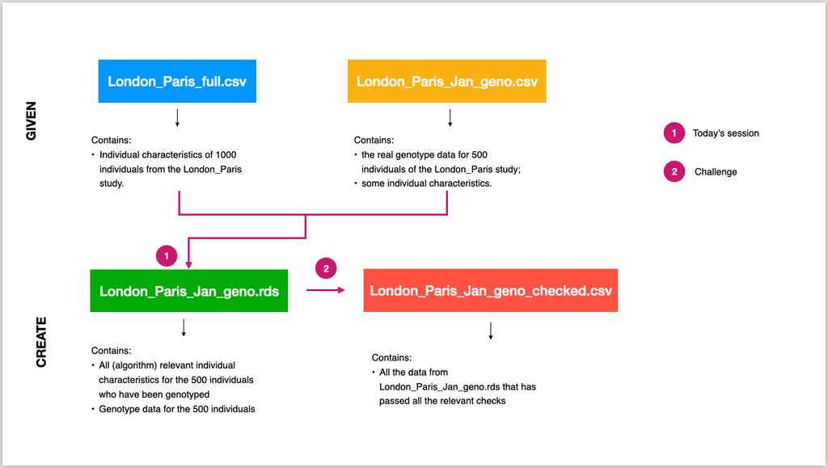

Overview of how we are going to help Françoise

## Creating the `London_Paris_info_geno.rds` object

In order to create the `London_Paris_info_geno` dataset we need to first understand what is contained in the data that our collaborator sent us and what is missing in that data.

To ensure that we are starting off with nothing in our R session we type in

```r
rm(list=ls())
```

### Loading `London_Paris_Jan_geno.csv`

We first load and explore the data that our collaborator sent us in the `London_Paris_Jan_geno.csv` file, which contains the genotype information on 500 individuals from the London_Paris study.

```r
LP_Jan_geno<-as_tibble(read.csv("Data/London_Paris_Jan_geno.csv",header=TRUE))
head(LP_Jan_geno)
```

```
## # A tibble: 6 × 14
##   sample…¹ X2    country   sex center age_r…² a_sta…³ a_qui…⁴ dodiag  SNP1  SNP2
##   <chr>    <lgl> <chr>   <int> <chr>    <dbl>   <int>   <dbl> <chr>  <int> <int>
## 1 A00001_… NA    7           2 41        62.7      21      NA <NA>       1     1
## 2 A00001_… NA    4           2 92        39.8      NA      NA 19jan…     0     1
## 3 A00001_… NA    1           2 81        67.6      NA      NA 04jul…     1     2
## 4 A00001_… NA    B           1 52        55.6      NA      NA <NA>       2     0
## 5 A00001_… NA    6           1 34        62.3      NA      NA <NA>       1     1
## 6 A00001_… NA    5           2 42        51.6      18      25 <NA>       1     2
## # … with 3 more variables: SNP3 <int>, SNP4 <int>, SNP5 <int>, and abbreviated
## #   variable names ¹sample_id, ²age_recr, ³a_sta_smok, ⁴a_quit_smok
```

```r
dim(LP_Jan_geno)
```

```
## [1] 500  14
```

```r
str(LP_Jan_geno)
```

```
## tibble [500 × 14] (S3: tbl_df/tbl/data.frame)
##  $ sample_id  : chr [1:500] "A00001_0059" "A00001_0845" "A00001_0481" "A00001_0309" ...
##  $ X2         : logi [1:500] NA NA NA NA NA NA ...
##  $ country    : chr [1:500] "7" "4" "1" "B" ...
##  $ sex        : int [1:500] 2 2 2 1 1 2 2 2 2 1 ...
##  $ center     : chr [1:500] "41" "92" "81" "52" ...
##  $ age_recr   : num [1:500] 62.7 39.8 67.6 55.6 62.3 ...
##  $ a_sta_smok : int [1:500] 21 NA NA NA NA 18 20 21 15 17 ...
##  $ a_quit_smok: num [1:500] NA NA NA NA NA 25 NA NA NA NA ...
##  $ dodiag     : chr [1:500] NA "19jan2009" "04jul1995" NA ...
##  $ SNP1       : int [1:500] 1 0 1 2 1 1 2 1 0 2 ...
##  $ SNP2       : int [1:500] 1 1 2 0 1 2 1 0 0 2 ...
##  $ SNP3       : int [1:500] 1 2 1 1 0 0 0 1 0 1 ...
##  $ SNP4       : int [1:500] 0 0 0 0 0 0 1 0 1 0 ...
##  $ SNP5       : int [1:500] 0 2 1 2 1 1 2 2 2 1 ...
```

```r
sum(is.na(LP_Jan_geno$X2))
```

```
## [1] 500
```

The column names of `London_Paris_Jan_geno` are

```r
colnames(LP_Jan_geno)
```

```
##  [1] "sample_id"   "X2"          "country"     "sex"         "center"
##  [6] "age_recr"    "a_sta_smok"  "a_quit_smok" "dodiag"      "SNP1"
## [11] "SNP2"        "SNP3"        "SNP4"        "SNP5"
```

From the problem description we saw that for the algorithm to run, we need the following individual characteristics:

- `sample_id` - study id
- `dob` - date of birth
- `dor` - date of recruitment in the study
- `dod` - date of death, coded as 19000101 for alive participants
- `dodiag` - date of diagnosis, coded as 19000101 for controls
- `cc_status` - case control status, 0 - control, 1 - case
- `smoke_status` - smoking status, 1 - never smoked, 2 - former smoker, 3 - current smoker
- `vit_status` - vital status, 1 - alive, 2 - dead
- `a_sta_smok` - age the individual started smoking, coded as 120 for never smokers
- `a_quit_smok` - age the individual stopped smoking, coded as 120 for current ans never smokers
- `age_recr` - age at recruitment in study

From what we have seen so far, we are missing several columns. We can also see that the `London_Paris_Jan_geno` data contains columns that we don’t need, such as, gender, for example. The missing information should be available in the `London_Paris_full.csv` data, which contains all the individual characterisitcs of our samples, as explained in the problem description.

### Loading `London_Paris_full.csv`

To load and explore the `London_Paris_full` data we do the following:

```r
LP_full<-read.csv("Data/London_Paris_full.csv")
head(LP_full)
```

```
##     sample_id       dob       dor       dod    dodiag sex cc_status
## 1 A00001_0420 19nov1936 15aug1993      <NA> 03nov2004   1         1
## 2 A00001_0445 14mar1939 24dec1998 24sep2004 21may2004   2         0
## 3 A00001_0298 05feb1924 22aug1996 24sep2004 08dec2004   1         1
## 4 A00001_0575 06jul1938 04may1994 25sep2004      <NA>   2         0
## 5 A00001_0280 22jul1931 19jan1998      <NA> 09nov2006   1         1
## 6 A00001_0471 12jun1941 15jul1993      <NA> 04mar2004   1         1
##   smoke_status country center vit_status a_sta_smok a_quit_smok age_recr
## 1            2       7     61          1         16          65 57.83436
## 2            2       1     52          2         18          NA 53.53046
## 3            3       7     42          2         18          NA 64.01369
## 4            3       9     92          2         20          NA 41.80424
## 5            3       8     31          1         13          NA 30.17385
## 6            2       5     13          1         22          NA 72.20260
##   n_cigret_lifetime
## 1             17.16
## 2             19.95
## 3             22.20
## 4                NA
## 5             20.00
## 6             11.76
```

```r
dim(LP_full)
```

```
## [1] 1000   15
```

```r
str(LP_full)
```

```
## 'data.frame':    1000 obs. of  15 variables:
##  $ sample_id        : chr  "A00001_0420" "A00001_0445" "A00001_0298" "A00001_0575" ...
##  $ dob              : chr  "19nov1936" "14mar1939" "05feb1924" "06jul1938" ...
##  $ dor              : chr  "15aug1993" "24dec1998" "22aug1996" "04may1994" ...
##  $ dod              : chr  NA "24sep2004" "24sep2004" "25sep2004" ...
##  $ dodiag           : chr  "03nov2004" "21may2004" "08dec2004" NA ...
##  $ sex              : int  1 2 1 2 1 1 1 1 1 1 ...
##  $ cc_status        : int  1 0 1 0 1 1 0 0 0 1 ...
##  $ smoke_status     : int  2 2 3 3 3 2 3 1 3 2 ...
##  $ country          : chr  "7" "1" "7" "9" ...
##  $ center           : chr  "61" "52" "42" "92" ...
##  $ vit_status       : int  1 2 2 2 1 1 1 1 1 1 ...
##  $ a_sta_smok       : int  16 18 18 20 13 22 15 14 17 NA ...
##  $ a_quit_smok      : num  65 NA NA NA NA NA NA 40 NA NA ...
##  $ age_recr         : num  57.8 53.5 64 41.8 30.2 ...
##  $ n_cigret_lifetime: num  17.2 19.9 22.2 NA 20 ...
```

We can also see that that it has the following columns:

```r
colnames(LP_full)
```

```
##  [1] "sample_id"         "dob"               "dor"
##  [4] "dod"               "dodiag"            "sex"
##  [7] "cc_status"         "smoke_status"      "country"
## [10] "center"            "vit_status"        "a_sta_smok"
## [13] "a_quit_smok"       "age_recr"          "n_cigret_lifetime"
```

and that as expected, it contains the information we need.

So now, what we have to do is combine these two datasets to obtain our `London_Paris_info_geno.rds` object.

### Creating `London_Paris_info_geno.rds`

There are several ways that we can go about doing this. In order to demonstrate the capabilities of the `tidyverse` package and use some of the `apply()` family functions we are going to do the following:

1. Obtain the relevant characteristics from the `London_Paris_full` data for the genotyped samples contained in `London_Paris_Jan_geno`
2. Merge the genotype information to the data obtained in the previous step, making sure that we don’t mix up the sample_ids.
3. Tranform relevant columns into factors and dates
4. Recode all dates so that they are in the format YYYYMMDD
5. Make sure `120` and `19000101` are coded when required
6. Confirm that the levels of the data are as expected. For example, there is no other level then 3 in the `smoke_status` column or that there are only two levels in the `vit_status` column
7. Check if there are any NAs remaining
8. Arranging our data by `cc_status` and `sample_id` so that controls appear first.
9. Save our final object as an .rds object.

**1. Obtaining relevant characteristics for the genotyped samples**

From what we have seen so far, we know that we require only certain columns from the `London_Paris_full` data and that we only need some of the samples in that data.

In order to **select** the relevant columns and **filter** the `London_Paris_full` data on the relevant samples we are going to create the following objects:

```r
algo.colnames<-c("sample_id","dob","dor","dod","dodiag","cc_status","smoke_status","vit_status","a_sta_smok","a_quit_smok","age_recr")
length(algo.colnames)
```

```
## [1] 11
```

```r
geno_samples<-LP_Jan_geno$sample_id
length(geno_samples)
```

```
## [1] 500
```

so that we can use these to **filter** out the irrelevant samples from the `LP_full` data and **select** the columns that we desire. As we will need this subset of data further down the line, we store it as `London_Paris_Jan_info` as follows:

```r
London_Paris_Jan_info<-filter(LP_full,sample_id %in% geno_samples) %>%
  select(algo.colnames)
head(London_Paris_Jan_info)
```

```
##     sample_id       dob       dor       dod    dodiag cc_status smoke_status
## 1 A00001_0445 14mar1939 24dec1998 24sep2004 21may2004         0            2
## 2 A00001_0201 06nov1956 27jun1995 02aug1998 03may2005         0            3
## 3 A00001_0641 07nov1945 25sep1995      <NA>      <NA>         0            1
## 4 A00001_0915 15nov1956 20nov1998 25jan1995 15apr1997         1            2
## 5 A00001_0418 09feb1940 25sep1992 22may2001      <NA>         0            3
## 6 A00001_0292 07dec1937 19jun1995      <NA> 01nov1999         1            3
##   vit_status a_sta_smok a_quit_smok age_recr
## 1          2         18          NA 53.53046
## 2          1         15          NA 30.62012
## 3          1         14          40 59.31280
## 4          1         NA          NA 51.20329
## 5          2         24          NA 55.38672
## 6          1         21          NA 50.45038
```

As expected we end up with an object that has 500 rows and 11 columns.

```r
dim(London_Paris_Jan_info)
```

```
## [1] 500  11
```

**Code explanation - dplyr::select, dplyr::filter and purrr::%>%**

The `filter` and `select` are two very handy functions that belong to the `dplyr` package and operate on rows and columns, respectively.

The `%>%` operator is called the pipe operator and allows us to make our code look nicer to the eye and avoid repetition in our code. It is part of the `purrr` package. It essentially tell us, submit what is on the left-hand side of the expression to the right hand side of the expression. So in the case above, it is saying:

- First create the object `London_Paris_Jan_info` by filtering on the `sample_id` in `geno_samples`
- Then, from that object select only the columns in `algo.colnames`.

Note that

```r
London_Paris_Jan_info<-filter(LP_full,sample_id %in% geno_samples) %>%
  select(algo.colnames)
```

is equivalent to

```r
London_Paris_Jan_info<-filter(LP_full,sample_id %in% geno_samples)

London_Paris_Jan_info<-select(London_Paris_Jan_info,algo.colnames)
```

**2. Merging with the genotype information**

Now that we have all of the individual characteristics of the genotyped samples from the `London_Paris` study in an object called `London_Paris_Jan_info`, we want to add the genotype information to this data object.

To do this, we first **select**, from `LP_Jan_geno`, only the columns that contain the SNP information. We also want to keep the column `sample_id` so that we don’t lose track of the ids of each row. Thus, we create the object `London_Paris_Jan_geno` that contains this information.

```r
London_Paris_Jan_geno<-LP_Jan_geno %>%
  select(sample_id,starts_with("SNP"))

head(London_Paris_Jan_geno)
```

```
## # A tibble: 6 × 6
##   sample_id    SNP1  SNP2  SNP3  SNP4  SNP5
##   <chr>       <int> <int> <int> <int> <int>
## 1 A00001_0059     1     1     1     0     0
## 2 A00001_0845     0     1     2     0     2
## 3 A00001_0481     1     2     1     0     1
## 4 A00001_0309     2     0     1     0     2
## 5 A00001_0699     1     1     0     0     1
## 6 A00001_0363     1     2     0     0     1
```

**Code explanation - dplyr - select helpers**

Notice that in the code above we have used one of the `select` helpers `starts_with`. This allows us to select all of the columns that start with “SNP” rather than having to select each of the columns individually as follows:

```r
London_Paris_Jan_geno<-LP_Jan_geno %>%
  select(sample_id,SNP1,SNP2,SNP3,SNP4,SNP5)
```

For other `select` helpers see for example [this page](https://www.rdocumentation.org/packages/dplyr/versions/0.7.2/topics/select_helpers).

We are now in the conditions of **joining** `London_Paris_Jan_info` with `London_Paris_Jan_geno`. Notice that they have a column in common which is `sample_id`. We will use this column to make sure we join the datasets by the appropriate rows.

This is simply done by executing the following code:

```r
LP_Jan_info_geno<-merge(London_Paris_Jan_info,London_Paris_Jan_geno,by="sample_id")

head(LP_Jan_info_geno)
```

```
##     sample_id       dob       dor       dod    dodiag cc_status smoke_status
## 1 A00001_0002 27dec1928 29apr1997      <NA>      <NA>         0            3
## 2 A00001_0003 25jan1954 08apr1997      <NA> 17may1999         0            2
## 3 A00001_0009 07mar1945 08sep1998      <NA> 23jun1998         1            3
## 4 A00001_0010 03jul1942 17nov1995 18oct2002 12jul2004         0            2
## 5 A00001_0011 08feb1934 08jan1997      <NA> 03jul2006         1            3
## 6 A00001_0012 15aug1953 15mar1996      <NA>      <NA>         0            1
##   vit_status a_sta_smok a_quit_smok age_recr SNP1 SNP2 SNP3 SNP4 SNP5
## 1          1         15          NA 67.49350    1    2    2    1    0
## 2          1         15          52 54.43121    2    2    0    0    2
## 3          1         18          NA 42.97331    0    2    0    1    0
## 4          2         NA          38 53.65092    1    2    1    0    0
## 5          1         20          NA 65.95209    2    1    2    0    2
## 6          1         36          64 48.97194    1    1    0    1    0
```

```r
dim(LP_Jan_info_geno)
```

```
## [1] 500  16
```

Thus, we now have our `LP_Jan_info_geno` dataset which contains 500 rows and 16 columns

**Code explanation - dplyr - mutating joins**

Alternatively, we could have used the below code to join the tables as well:

```r
LP_Jan_info_geno<-left_join(London_Paris_Jan_info,London_Paris_Jan_geno,by="sample_id")
```

This alternative uses the mutating join functions of `dplyr`. You can find more information on these [here](https://r4ds.had.co.nz/relational-data.html#mutating-joins).

**3. Transforming relevant columns into factors and dates**

Now that we have an object that contains all of the relevant data for the genotyped samples we need to make sure that the dates are transformed into dates and that factors are coded appropriately. We can do this very easily using the function `mutate` from the dplyr function.

```r
LP_Jan_info_geno <- LP_Jan_info_geno %>%
  mutate(
  sample_id=as.character(sample_id),
  dob = as.Date(dob, "%d%b%Y"),
  dor = as.Date(dor,"%d%b%Y"),
  dod = as.Date(dod,"%d%b%Y"),
  dodiag = as.Date(dodiag,"%d%b%Y"),
  cc_status = as.factor(cc_status),
  smoke_status = as.factor(smoke_status),
  vit_status = as.factor(vit_status)
)

head(LP_Jan_info_geno)
```

```
##     sample_id        dob        dor        dod     dodiag cc_status
## 1 A00001_0002 1928-12-27 1997-04-29       <NA>       <NA>         0
## 2 A00001_0003 1954-01-25 1997-04-08       <NA> 1999-05-17         0
## 3 A00001_0009 1945-03-07 1998-09-08       <NA> 1998-06-23         1
## 4 A00001_0010 1942-07-03 1995-11-17 2002-10-18 2004-07-12         0
## 5 A00001_0011 1934-02-08 1997-01-08       <NA> 2006-07-03         1
## 6 A00001_0012 1953-08-15 1996-03-15       <NA>       <NA>         0
##   smoke_status vit_status a_sta_smok a_quit_smok age_recr SNP1 SNP2 SNP3 SNP4
## 1            3          1         15          NA 67.49350    1    2    2    1
## 2            2          1         15          52 54.43121    2    2    0    0
## 3            3          1         18          NA 42.97331    0    2    0    1
## 4            2          2         NA          38 53.65092    1    2    1    0
## 5            3          1         20          NA 65.95209    2    1    2    0
## 6            1          1         36          64 48.97194    1    1    0    1
##   SNP5
## 1    0
## 2    2
## 3    0
## 4    0
## 5    2
## 6    0
```

**Code explanation - dplyr::mutate**

As its name indicates, the function `mutate` from `dplyr` allows us to **mutate** existing columns by either creating new ones or recreating old ones. Here, we used mutate to recreate old columns but you can try the following to create a new column in the `LP_Jan_info_geno` data:

```r
test_mutate<-LP_Jan_info_geno %>%
  mutate(vit_status_test=ifelse(vit_status==1,1,0))

dim(test_mutate)
```

```
## [1] 500  17
```

```r
dim(LP_Jan_info_geno)
```

```
## [1] 500  16
```

Notice that mutate appends the new columns to the data. If you wanted to just create the new column from the data you could use the function `transmute()`. See [here](https://r4ds.had.co.nz/transform.html#add-new-variables-with-mutate) for more information on these dplyr functions.

**4. Recoding of dates into YYYYMMDD format**

As we saw in the problem description, all the dates need to be coded in the format YYYYMMDD. In the previous step we transformed the columns containing dates into date objects, however, these are in the format YYYY-MM-DD, which is not what we desire. To remove the hyphens from the date objects we will use the function `str_replace_all` from the `stringr` package, which allows us to replace characters in strings by something else. To do this we do first create a function called `sub_hifen` that does exactly that and then change the relevant columns by using the function `mutate`.

```r
sub_hifen<-function(x){
  x<-str_replace_all(x,"-","")
}

LP_Jan_info_geno<- LP_Jan_info_geno %>%
  mutate_at(vars(starts_with("d")),sub_hifen)
```

For more information on the `stringr` package have a look [here](https://r4ds.had.co.nz/strings.html).

**5. Making sure `120` and `19000101` are coded when required**

Recall from the problem description that:

- `dod` should be coded as 19000101 for alive participants;
- `dodiag` should be coded as 19000101 for controls;
- `a_sta_smok` should be coded as 120 for never smokers;
- `a_quit_smok` should be coded as 120 for current and never smokers.

To do this we will again use the function **mutate** as follows:

```r
LP_Jan_info_geno <- LP_Jan_info_geno %>%
  mutate(dod=ifelse(vit_status==1 & is.na(dod),19000101,dod),
         dodiag=ifelse(cc_status==0 & is.na(dodiag),19000101,dodiag),
         a_sta_smok=ifelse(smoke_status==1 & is.na(a_sta_smok),120,a_sta_smok),
         a_quit_smok=ifelse(is.na(a_quit_smok) & (smoke_status==1 | smoke_status==3),120,a_quit_smok))

head(LP_Jan_info_geno)
```

```
##     sample_id      dob      dor      dod   dodiag cc_status smoke_status
## 1 A00001_0002 19281227 19970429 19000101 19000101         0            3
## 2 A00001_0003 19540125 19970408 19000101 19990517         0            2
## 3 A00001_0009 19450307 19980908 19000101 19980623         1            3
## 4 A00001_0010 19420703 19951117 20021018 20040712         0            2
## 5 A00001_0011 19340208 19970108 19000101 20060703         1            3
## 6 A00001_0012 19530815 19960315 19000101 19000101         0            1
##   vit_status a_sta_smok a_quit_smok age_recr SNP1 SNP2 SNP3 SNP4 SNP5
## 1          1         15         120 67.49350    1    2    2    1    0
## 2          1         15          52 54.43121    2    2    0    0    2
## 3          1         18         120 42.97331    0    2    0    1    0
## 4          2         NA          38 53.65092    1    2    1    0    0
## 5          1         20         120 65.95209    2    1    2    0    2
## 6          1         36          64 48.97194    1    1    0    1    0
```

**6. Confirming that all levels of the data are as expected**

Now that we have our dates in the format that we desire, we need to confirm that all the columns that are categorical don’t have any unexpected levels in them. Recall that the levels should be as follows:

- `cc_status`, 0-controls, 1-cases
- `smoke_status`, 1-never smokers, 2-former smokers, 3-current smokers
- `vit_status`, 1-alive, 2-dead
- SNP colums should only have 3 levels, 0,1 and 2.

To investigate this in our data we are going to make use of the `lapply` function from the `apply()` family of the base R functions. We use `lapply` to obtain a table of counts for each of the columns we are interested in.

```r
inspect_levels<-select(LP_Jan_info_geno,cc_status,smoke_status,vit_status,starts_with("SNP")) %>%
  lapply(table)

inspect_levels
```

```
## $cc_status
##
##   0   1
## 250 250
##
## $smoke_status
##
##   1   2   3   4
## 143 130 217  10
##
## $vit_status
##
##   1   2   6   8
## 285 210   1   4
##
## $SNP1
##
##   0   1   2
## 166 167 167
##
## $SNP2
##
##   0   1   2
## 166 167 167
##
## $SNP3
##
##   0   1   2
## 166 167 167
##
## $SNP4
##
##   0   1   2
## 166 167 167
##
## $SNP5
##
##   0   1   2
## 166 167 167
```

From what we can see the columns `smoke_status` and `vit_status` have some unwanted categories. We will remove these from our data by filtering them out as follows:

```r
LP_Jan_info_geno<-LP_Jan_info_geno %>%
                        filter(smoke_status!=4,vit_status %in% c(1,2))

dim(LP_Jan_info_geno)
```

```
## [1] 485  16
```

We can now confirm that the levels are as required by inspecting the individual tables as follows:

```r
table(LP_Jan_info_geno$smoke_status)
```

```
##
##   1   2   3   4
## 143 128 214   0
```

```r
table(LP_Jan_info_geno$vit_status)
```

```
##
##   1   2   6   8
## 280 205   0   0
```

**Code explanation - lapply from the apply() family of functions** The apply family of functions allows us to apply different functions to different data structures. There is, for example:

- `apply()` - applies a function over an array of margins
- `lapply()` - applies a function over a list or a vector
- `sapply()` - is a friendlier version of lapply and allows us to return, when appropriate, a vector or a matrix. In the example above we could have used `sapply` as well.

Essentially, the choice of the `_apply()` function will depend on what is your input and what you want as an output.

In this case we wanted to return a list where each element of the list contains a table with the counts for each column of interest. `lapply()` returns a list. We can use also use the `sapply` function and the `apply()` functions here as well and will obtain the same result.

For more information on the `apply()` family of functions see [this](https://www.datacamp.com/community/tutorials/r-tutorial-apply-family#codelapplycode) `apply` tutorial by Datacamp or [this Wordpress article](https://nsaunders.wordpress.com/2010/08/20/a-brief-introduction-to-apply-in-r/).

**7. Checking if there are any NAs remaining**

As the algorithm that Françoise has developed is not NA friendly, we have to check that none of the rows of the data has any NAs remaining. To do this we will again make use of the `apply()` family of functions and the function `dplyr::filter`. First we inspect if there are any NAs remaining as follows:

```r
na_test<-select(LP_Jan_info_geno,sample_id:age_recr) %>%
  lapply(is.na) %>%
  sapply(sum,simplify=TRUE)

na_test
```

```
##    sample_id          dob          dor          dod       dodiag    cc_status
##            0            0            0            0            0            0
## smoke_status   vit_status   a_sta_smok  a_quit_smok     age_recr
##            0            0          104           95            0
```

As we can see there are still some NAs in `a_sta_smok` and `a_quit_smok`. So we filter them out using the `filter` function:

```r
LP_Jan_info_geno<-filter(LP_Jan_info_geno,!is.na(a_sta_smok),!is.na(a_quit_smok))

dim(LP_Jan_info_geno)
```

```
## [1] 326  16
```

So we have gone from having 500 observations to 326.

Let us finally **arrange** the data by `cc_status` and `sample_id` so that we can then store it as an .rds object to then perform the further checks on the dates, in the next section.

**8. Arranging our data by `cc_status` and `sample_id`**

We are now interested in **arranging** our data by `cc_status` and then by `sample_id`. This is easily achieved by using the `arrange` function from the `dplyr` pacakge. At the moment we can see that our data is arranged by ascending order of `sample_id`. This was automatically done when we did the merging of the datasets by `sample_id` in step 2.

```r
head(LP_Jan_info_geno)
```

```
##     sample_id      dob      dor      dod   dodiag cc_status smoke_status
## 1 A00001_0002 19281227 19970429 19000101 19000101         0            3
## 2 A00001_0003 19540125 19970408 19000101 19990517         0            2
## 3 A00001_0009 19450307 19980908 19000101 19980623         1            3
## 4 A00001_0011 19340208 19970108 19000101 20060703         1            3
## 5 A00001_0012 19530815 19960315 19000101 19000101         0            1
## 6 A00001_0016 19250209 19931122 19000101 19970708         1            3
##   vit_status a_sta_smok a_quit_smok age_recr SNP1 SNP2 SNP3 SNP4 SNP5
## 1          1         15         120 67.49350    1    2    2    1    0
## 2          1         15          52 54.43121    2    2    0    0    2
## 3          1         18         120 42.97331    0    2    0    1    0
## 4          1         20         120 65.95209    2    1    2    0    2
## 5          1         36          64 48.97194    1    1    0    1    0
## 6          1         17         120 48.96646    0    2    1    0    1
```

We want to rearrange the data so that controls come first and cases afterwards, and then within `cc_status` group the observations according to `sample_id`. To do this we execute the following:

```r
LP_Jan_info_geno<-arrange(LP_Jan_info_geno,cc_status,sample_id)

head(LP_Jan_info_geno)
```

```
##     sample_id      dob      dor      dod   dodiag cc_status smoke_status
## 1 A00001_0002 19281227 19970429 19000101 19000101         0            3
## 2 A00001_0003 19540125 19970408 19000101 19990517         0            2
## 3 A00001_0012 19530815 19960315 19000101 19000101         0            1
## 4 A00001_0023 19390801 19930618 20060818 20000912         0            3
## 5 A00001_0024 19560911 19950627 19000101 19000101         0            1
## 6 A00001_0025 19530815 19950421 20050804 20070117         0            1
##   vit_status a_sta_smok a_quit_smok age_recr SNP1 SNP2 SNP3 SNP4 SNP5
## 1          1         15         120 67.49350    1    2    2    1    0
## 2          1         15          52 54.43121    2    2    0    0    2
## 3          1         36          64 48.97194    1    1    0    1    0
## 4          2         36         120 54.35455    0    0    2    0    1
## 5          1         18          61 46.59822    1    0    0    2    0
## 6          1        120         120 56.57769    1    0    2    2    1
```

As expected, the `cc_status` and `sample_id` columns have been rearranged as desired.

**9. Saving our final object as an .rds object**

Now that we have our data in the desired format, we can save it to the `Data` folder as an .rds object called `London_Paris_info_geno.rds` as follows:

```r
saveRDS(LP_Jan_info_geno,"Data/London_Paris_info_geno.rds")
```

Let us now move to the next section where we are going to perform some checks on the dates and ages.

## Performing date and age checks - Challenge

**CHALLENGE**

Now that you have learned some of the basic functions from the `dplyr` package and some functions of the `apply()` family you will now use what you have learned to perform the relevant checks on the dates and ages in order to create our final object `London_Paris_info_geno_checked.rds`.

Recall from the problem description we have to perform the following checks:

1. the date of diagnosis has to be greater than the recruitment date
2. the date of diagnosis has to be greater than the birth date
3. the recruitment date has to be greater than the birth date
4. if a patient has been diagnosed with lung cancer and the patient died, than the death date has to be greater than the diagnosis date
5. the date of death has to be greater than the recruitment date
6. if the vital_status = 1 then no death date should be observed
7. if the vital_status = 2 then a death date should be observed
8. if there is a death date then the death date should be greater than the birth date
9. if an observation is a case then there must be a diagnosis date
10. if an observations is not a case then there shouldn’t be a diagnosis date
11. if an observation is a former or current smoker, the age of starting smoking should be registered
12. if an observation is a former smoker than age of quitting smoking should be registered
13. for former smokers, the age of quitting should be greater than or equal to the age of starting smoking.

**Tips** There are several ways you can solve this problem. In order to help you we have devised a 3 step plan that you may or may not want to follow.

1. Create a dataframe that contains, for each condition, an indicator column, informing us on whether or not each observation passes the check;
2. Determine the amount of observations that failed each of the checks.
3. Remove the “failed” ids from the dataset and save our final object as `London_Paris_info_geno_checked.rds.`

**Note:** For step 1 you might want to call your columns

- dodiag_recrui_ch
- dodiag_birth_ch
- dor_dob_ch
- dod_dodiag_ch
- dod_dor_ch
- dod_vital_ch_1
- dod_vital_ch_2
- dod_dob_ch
- cc_status_ch_1
- cc_status_ch_0
- sta_smoke_date_ch
- quit_smoke_date_ch
- quit_sta_smoke_date_ch

For steps 2 and 3 you might want to use the commands `summarise_at` and `filter_at`. You can find some details on these functions [here](https://dplyr.tidyverse.org/reference/scoped.html) and [here](https://suzan.rbind.io/2018/01/dplyr-tutorial-1/).

# Resources

There are plenty of resources for R, available online. In this section we have consolidated a few.

- [The “Bible of R” - R for data Science by H Wickham and G Grolemund](https://r4ds.had.co.nz/)
- More on factors - [here](https://r4ds.had.co.nz/factors.html) and [here](http://swcarpentry.github.io/r-novice-inflammation/12-supp-factors/index.html).
- [More on manipulating dates](https://r4ds.had.co.nz/dates-and-times.html)
- [More on dplyr functions](https://r4ds.had.co.nz/transform.html)
- [More on manipulating strings](https://r4ds.had.co.nz/strings.html)
- More on the `apply()` family of functions: [here](https://www.datacamp.com/community/tutorials/r-tutorial-apply-family#codelapplycode) and [here](https://nsaunders.wordpress.com/2010/08/20/a-brief-introduction-to-apply-in-r/)